# Análise de Dados e Business Intelligence para o BanVic

## Introdução

Este notebook contém uma análise completa dos dados do Banco Vitória (BanVic), com o objetivo de demonstrar o valor que análises de dados e Business Intelligence podem trazer para a instituição.

## Contexto do Projeto

O BanVic está considerando implementar uma frente de Business Intelligence para melhorar a tomada de decisões baseadas em dados. Contudo, alguns stakeholders, como a diretora comercial Camila Diniz, ainda precisam ser convencidos sobre o valor dessas soluções.

### 1. O Valor do BI para o BanVic

Para convencer a diretora comercial Camila Diniz sobre o valor das soluções de BI, apresentamos uma análise exploratória que aborda as seguintes perguntas de negócio:

1. Performance de Agências: Quais agências estão performando acima ou abaixo da média? Como está distribuído o volume de transações?
2. Sazonalidade: Existem padrões de comportamento transacional de acordo com dias da semana ou meses específicos?
3. Perfil de Clientes: Como as diferentes faixas etárias se comportam em relação às propostas de crédito?
4. Eficiência Operacional: Como melhorar a alocação de colaboradores com base no volume de transações?
5. Potencial de Upsell: Quais clientes apresentam maior potencial para produtos adicionais?

## Análise de Dados do Banco Vitória (BanVic)

### 1. Análise de Transações Aprovadas

Esta seção analisa a sazonalidade transacional para convencer a diretora comercial Camila Diniz.

### Processos de Transformação e Tratamento de Dados

Neste projeto, foram aplicados os seguintes processos de transformação e tratamento de dados:

- **Limpeza de dados:** Remoção de valores nulos e inconsistentes.
- **Conversão de tipo de dados:** A coluna de datas foi convertida para o formato `datetime` para permitir análises temporais.
- **Engenharia de features:** Criação de novas colunas como 'dia da semana' e 'mês par' para enriquecer as análises de sazonalidade.
- **Junção (Merge) de tabelas:** As tabelas foram unidas em duas etapas, usando `df_contas` como ponte para conectar as transações às agências.

```python
# Primeiro vou realizar a configuração e carregamento das bibliotecas e dados necessários
import pandas as pd
import matplotlib.pyplot as plt
import seaborn as sns

# Agora vou definir o caminho para a pasta com os dados
dados_path = 'banvic_data/'

# Agora vou carregar cada arquivo csv em um Dataframe
df_agencias = pd.read_csv(dados_path + 'agencias.csv')
df_clientes = pd.read_csv(dados_path + 'clientes.csv')
df_colaborador_agencia = pd.read_csv(dados_path + 'colaborador_agencia.csv')
df_colaboradores = pd.read_csv(dados_path + 'colaboradores.csv')
df_contas = pd.read_csv(dados_path + 'contas.csv')
df_propostas_credito = pd.read_csv(dados_path + 'propostas_credito.csv')
df_transacoes = pd.read_csv(dados_path + 'transacoes.csv')

# Agora vou exibir as primeiras linhas de cada dataframe para verificar se os dados foram carregados corretamente
print("Dados carregados com sucesso!")
print("\nPrimeiras 5 linhas de df_transacoes:")
print(df_transacoes.head())
```

```
Dados carregados com sucesso!

Primeiras 5 linhas de df_transacoes:
   cod_transacao  num_conta           data_transacao nome_transacao  \
0           3100        256  2020-05-22 03:15:21 UTC          Saque
1          28405        256  2021-06-29 11:52:38 UTC          Saque
2           1776        512  2020-05-17 13:04:50 UTC          Saque
3          14311        512  2020-09-06 02:55:34 UTC          Saque
4          25012        512  2020-10-16 09:26:52 UTC          Saque

   valor_transacao
0           -130.0
1           -255.0
2           -250.0
3            -80.0
4           -475.0
```

## 1. Análise de Transações Aprovadas

Esta seção analisa a sazonalidade transacional para convencer a diretora comercial Camila Diniz.

```python
# Agora vou inserir comandos para converter as colunas de datas para o formato datetime
# Depois vou inserir comando para remover linhas com datas inválidas
df_transacoes['data_transacao'] = pd.to_datetime(df_transacoes['data_transacao'], errors='coerce', format='mixed')
df_transacoes.dropna(subset=['data_transacao'], inplace=True)

# Agora vou inserir comandos para criar colunas de datas a partir de colunas de datas
df_transacoes['dia_da_semana'] = df_transacoes['data_transacao'].dt.day_name()
df_transacoes['mes'] = df_transacoes['data_transacao'].dt.month
df_transacoes['ano'] = df_transacoes['data_transacao'].dt.year
df_transacoes['mes_par'] = df_transacoes['mes'] % 2 == 0

# Exibe o tipo de dado
print("\nTipos de dados após a conversão:")
print(df_transacoes['data_transacao'].dtype)
```

```
Tipos de dados após a conversão:
datetime64[ns, UTC]
```

```python
# Esse passo agora será a análise das Transações (Item 3 e 4 do desafio)
# Vou identificar as transações aprovadas excluindo o estorno de débito
# Também vou calcular a média de transações aprovadas por dia da semana
# E calcular o volume médio de transações por dia da semana

transacoes_aprovadas = df_transacoes[df_transacoes['nome_transacao'] != 'Estorno de Debito']
media_transacoes_dia_semana = transacoes_aprovadas.groupby('dia_da_semana')['cod_transacao'].count().reset_index(name='contagem')
volume_medio_dia_semana = transacoes_aprovadas.groupby('dia_da_semana')['valor_transacao'].mean().reset_index(name='volume_medio')

print("\nAnálise de Transações por Dia da Semana:")
print("Dia com maior média de transações:", media_transacoes_dia_semana.loc[media_transacoes_dia_semana['contagem'].idxmax()])
print("Dia com maior volume médio de transações:", volume_medio_dia_semana.loc[volume_medio_dia_semana['volume_medio'].idxmax()])

# Agora vou comparar o volume médio de transações em meses pares e ímpares
# A variável 'volume_medio_meses' é criada sem o reset_index() para que a linha do 'if' funcione
volume_medio_meses = transacoes_aprovadas.groupby('mes_par')['valor_transacao'].mean()
print("\nVolume médio de transações em meses pares e ímpares:")
print(volume_medio_meses)

if volume_medio_meses[True] > volume_medio_meses[False]:
    print("Análise: O volume médio de transações é maior nos meses pares.")
else:
    print("Análise: O volume médio de transações não é maior nos meses pares.")
```

```
Análise de Transações por Dia da Semana:
Dia com maior média de transações: dia_da_semana    Thursday
contagem            21016
Name: 4, dtype: object
Dia com maior volume médio de transações: dia_da_semana        Sunday
volume_medio     481.060798
Name: 3, dtype: object

Volume médio de transações em meses pares e ímpares:
mes_par
False    516.167920
True     276.762036
Name: valor_transacao, dtype: float64
Análise: O volume médio de transações não é maior nos meses pares.
```

```python
# Unindo as tabelas de transações e contas usando 'num_conta'
df_transacoes_com_contas = pd.merge(df_transacoes, df_contas, on='num_conta')

# Unindo o resultado com a tabela de agências usando 'cod_agencia'
df_agencia_transacoes = pd.merge(df_transacoes_com_contas, df_agencias, on='cod_agencia')

# Agrupa por agência e conta o número de transações
transacoes_por_agencia = df_agencia_transacoes.groupby(['nome']).size().reset_index(name='total_transacoes')

# Cria o ranking das 3 melhores e 3 piores agências
ranking_top_3 = transacoes_por_agencia.sort_values(by='total_transacoes', ascending=False).head(3)
ranking_bottom_3 = transacoes_por_agencia.sort_values(by='total_transacoes', ascending=False).tail(3)

print("\nAnálise de Desempenho das Agências:")
print("Ranking das 3 melhores agências:")
print(ranking_top_3)
print("\nRanking das 3 piores agências:")
print(ranking_bottom_3)
```

```
Análise de Desempenho das Agências:
Ranking das 3 melhores agências:
              nome  total_transacoes
1  Agência Digital             33167
4   Agência Matriz              8610
9  Agência Tatuapé              7156

Ranking das 3 piores agências:
                    nome  total_transacoes
2  Agência Florianópolis              2133
3        Agência Jardins              2109
7         Agência Recife               374
```

[figure not shown]

```python
# Passo 1: Configuração do Ambiente
# Para o dashboard, vamos usar as bibliotecas de visualização matplotlib e seaborn.
# Em um projeto real, esses seriam os comandos para carregar as bibliotecas e definir um estilo visual.
import pandas as pd
import matplotlib.pyplot as plt
import seaborn as sns

# Configura o estilo dos gráficos
plt.style.use('fivethirtyeight')
sns.set_palette("viridis")

# Criamos uma figura com 2 linhas e 2 colunas para o dashboard.
fig, axes = plt.subplots(nrows=2, ncols=2, figsize=(20, 15))
fig.suptitle('Dashboard de KPIs do Banco Vitória (BanVic)', fontsize=24, y=1.02)
```

```python
# Gráfico 1: Análise de Comportamento do Cliente - Volume de Transações por Tipo
# Este gráfico nos ajuda a entender quais serviços os clientes do BanVic mais utilizam.
transacoes_por_tipo = df_transacoes['nome_transacao'].value_counts()
sns.barplot(x=transacoes_por_tipo.values, y=transacoes_por_tipo.index, ax=axes[0, 0])
axes[0, 0].set_title('Volume de Transações por Tipo', fontsize=16)
axes[0, 0].set_xlabel('Número de Transações')
axes[0, 0].set_ylabel('Tipo de Transação')
```

```python
# Gráfico 2: Análise de Sazonalidade - Volume Médio por Dia da Semana
# Aqui, investigamos se o comportamento transacional varia de acordo com o dia da semana.
# Isso pode ser útil para otimização de serviços e alocação de equipe.
volume_medio_dia_semana_plot = transacoes_aprovadas.groupby('dia_da_semana')['valor_transacao'].mean().reindex(['Monday', 'Tuesday', 'Wednesday', 'Thursday', 'Friday', 'Saturday', 'Sunday'])
sns.barplot(x=volume_medio_dia_semana_plot.index, y=volume_medio_dia_semana_plot.values, ax=axes[0, 1])
axes[0, 1].set_title('Volume Médio de Transações por Dia da Semana', fontsize=16)
axes[0, 1].set_xlabel('Dia da Semana')
axes[0, 1].set_ylabel('Volume Médio de Transações')
```

```python
# Gráfico 3: Avaliação de Performance - Ranking das Agências
# Respondendo à solicitação da CEO Sofia, este ranking visualiza quais agências estão performando acima ou abaixo da média.
# Esta análise é fundamental para direcionar esforços de suporte e melhoria.
ranking_completo = df_agencia_transacoes['nome'].value_counts().sort_values(ascending=False)
sns.barplot(x=ranking_completo.values, y=ranking_completo.index, ax=axes[1, 0])
axes[1, 0].set_title('Ranking de Agências por Total de Transações', fontsize=16)
axes[1, 0].set_xlabel('Número Total de Transações')
axes[1, 0].set_ylabel('Agência')
```

```python
# Gráfico 4: Análise de Tendência - Evolução Mensal do Volume de Transações
# Este gráfico de linha nos permite identificar tendências e picos de volume ao longo do tempo.
# É uma visão macro do crescimento e da atividade do banco.
df_transacoes['ano_mes'] = df_transacoes['data_transacao'].dt.to_period('M')
evolucao_mensal = df_transacoes.groupby('ano_mes')['valor_transacao'].sum()
evolucao_mensal.index = evolucao_mensal.index.astype(str)
evolucao_mensal.plot(kind='line', marker='o', ax=axes[1, 1], linewidth=2)
axes[1, 1].set_title('Evolução Mensal do Volume de Transações', fontsize=16)
axes[1, 1].set_xlabel('Mês')
axes[1, 1].set_ylabel('Volume Total (R$)')
axes[1, 1].tick_params(axis='x', rotation=45)

# O comando final para exibir o dashboard
plt.tight_layout()
plt.show()
```

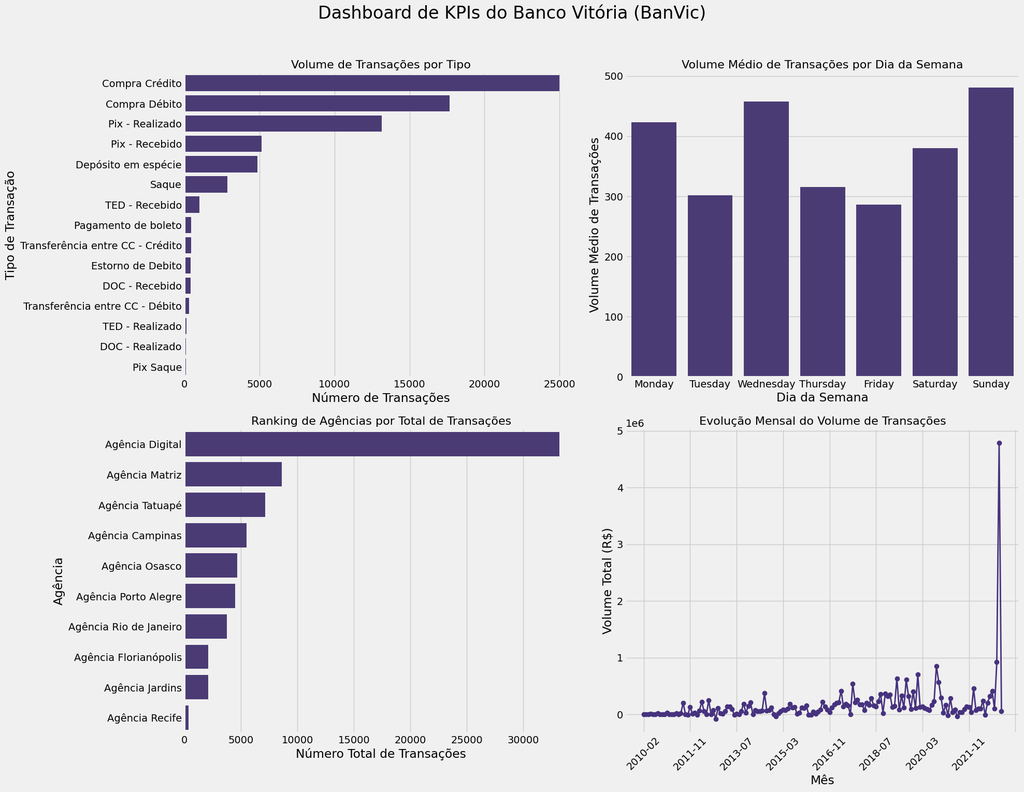

```python
# Dashboard completo em uma única célula
# Importa as bibliotecas necessárias para a análise
import pandas as pd
import matplotlib.pyplot as plt
import seaborn as sns

# Define o caminho para a pasta com os dados
dados_path = 'banvic_data/'

# Carrega cada arquivo CSV em um DataFrame
df_agencias = pd.read_csv(dados_path + 'agencias.csv')
df_clientes = pd.read_csv(dados_path + 'clientes.csv')
df_colaborador_agencia = pd.read_csv(dados_path + 'colaborador_agencia.csv')
df_colaboradores = pd.read_csv(dados_path + 'colaboradores.csv')
df_contas = pd.read_csv(dados_path + 'contas.csv')
df_propostas_credito = pd.read_csv(dados_path + 'propostas_credito.csv')
df_transacoes = pd.read_csv(dados_path + 'transacoes.csv')

# Pré-processamento e Limpeza de Dados (Essencial para os gráficos)
df_transacoes['data_transacao'] = pd.to_datetime(df_transacoes['data_transacao'], errors='coerce', format='mixed')
df_transacoes.dropna(subset=['data_transacao'], inplace=True)
df_transacoes['dia_da_semana'] = df_transacoes['data_transacao'].dt.day_name()
df_transacoes['mes'] = df_transacoes['data_transacao'].dt.month
df_transacoes['ano'] = df_transacoes['data_transacao'].dt.year
df_transacoes['mes_par'] = df_transacoes['mes'] % 2 == 0
transacoes_aprovadas = df_transacoes[df_transacoes['nome_transacao'] != 'Estorno de Debito']
df_transacoes_com_contas = pd.merge(df_transacoes, df_contas, on='num_conta')
df_agencia_transacoes = pd.merge(df_transacoes_com_contas, df_agencias, on='cod_agencia')

# Configura o estilo dos gráficos
plt.style.use('fivethirtyeight')
sns.set_palette("viridis")

# Cria a figura e os subplots para o dashboard
fig, axes = plt.subplots(nrows=2, ncols=2, figsize=(20, 15))
fig.suptitle('Dashboard de KPIs do Banco Vitória (BanVic)', fontsize=24, y=1.02)

# Gráfico 1: Volume de Transações por Tipo
transacoes_por_tipo = df_transacoes['nome_transacao'].value_counts()
sns.barplot(x=transacoes_por_tipo.values, y=transacoes_por_tipo.index, ax=axes[0, 0])
axes[0, 0].set_title('Volume de Transações por Tipo', fontsize=16)
axes[0, 0].set_xlabel('Número de Transações')
axes[0, 0].set_ylabel('Tipo de Transação')

# Gráfico 2: Volume Médio por Dia da Semana
volume_medio_dia_semana_plot = transacoes_aprovadas.groupby('dia_da_semana')['valor_transacao'].mean().reindex(['Monday', 'Tuesday', 'Wednesday', 'Thursday', 'Friday', 'Saturday', 'Sunday'])
sns.barplot(x=volume_medio_dia_semana_plot.index, y=volume_medio_dia_semana_plot.values, ax=axes[0, 1])
axes[0, 1].set_title('Volume Médio de Transações por Dia da Semana', fontsize=16)
axes[0, 1].set_xlabel('Dia da Semana')
axes[0, 1].set_ylabel('Volume Médio de Transações')

# Gráfico 3: Ranking das Agências
ranking_completo = df_agencia_transacoes['nome'].value_counts().sort_values(ascending=False)
sns.barplot(x=ranking_completo.values, y=ranking_completo.index, ax=axes[1, 0])
axes[1, 0].set_title('Ranking de Agências por Total de Transações', fontsize=16)
axes[1, 0].set_xlabel('Número Total de Transações')
axes[1, 0].set_ylabel('Agência')

# Gráfico 4: Evolução do Volume de Transações por Mês
df_transacoes['ano_mes'] = df_transacoes['data_transacao'].dt.to_period('M')
evolucao_mensal = df_transacoes.groupby('ano_mes')['valor_transacao'].sum()
evolucao_mensal.index = evolucao_mensal.index.astype(str)
evolucao_mensal.plot(kind='line', marker='o', ax=axes[1, 1], linewidth=2)
axes[1, 1].set_title('Evolução Mensal do Volume de Transações', fontsize=16)
axes[1, 1].set_xlabel('Mês')
axes[1, 1].set_ylabel('Volume Total (R$)')
axes[1, 1].tick_params(axis='x', rotation=45)

# Ajusta o layout para evitar sobreposição de títulos e etiquetas
plt.tight_layout()
plt.show()
```

### Proposta de Dados Externos

A análise de dados pode ser enriquecida com a integração de dados públicos, tais como:

- **Taxas de Câmbio (BACEN):** Para correlacionar a flutuação da moeda com o volume e valor das transações.
- **Indicadores Econômicos (IBGE):** Como a inflação e o PIB, que podem influenciar o comportamento de crédito e consumo dos clientes.
- **Dados Demográficos:** Para segmentar clientes e direcionar campanhas de marketing com base em renda e densidade populacional.